# Small-Fleet Trucking Rater

A rater for for-hire trucking, 1–5 power unit fleets, primary auto liability: submission in, bindable premium (or a defensible decline) out, priced off an explicit loss-cost-plus-margin view built from FMCSA Census and Crash data.

## What this notebook does

1. Pulls a calibration population of small-fleet carriers from FMCSA Census and matches 3 years of crash history from the FMCSA Crash file (Steps 1–13).
2. Builds a portfolio-calibrated, credibility-weighted frequency model restricted to the 1–5 power-unit target segment (Steps 14–17).
3. Takes a **submission** (USDOT number, drivers, power units, VINs, radius, commodity) and merges it with the FMCSA-derived facts to build a per-carrier profile, cross-checking declared figures against FMCSA and rating off the larger of the two (Steps 18, 21–22).
4. Prices the submission off an expected loss cost (frequency × a radius/commodity/hazmat-adjusted dollar severity), loaded for expenses and profit into a bindable premium (Steps 19, 23–24).
5. Applies underwriting rules — DECLINE (hard stop), REFER (needs manual review), or ACCEPT — kept separate from pricing (Step 20).
6. Wraps all of the above into one `rate_carrier(submission)` function with structured error handling, and a `run_book_check(submissions)` command that reports priced/referred/declined counts, decline rate, premium distribution, and any errors across a batch (Steps 25–27).

### Importing Libraries

```python
import time
import warnings
from pathlib import Path

import numpy as np
import pandas as pd
import requests

warnings.filterwarnings("ignore")
pd.set_option("display.max_columns", 100)
pd.set_option("display.width", 180)

print("Packages loaded.")
```

```
Packages loaded.
```

### Loading Datasets and Setting up Parameters

```python
# STEP 2 — Configuration

CENSUS_URL = "https://data.transportation.gov/resource/az4n-8mr2.json"
CRASH_URL  = "https://data.transportation.gov/resource/aayw-vxb3.json"

# Use 50,000 carriers for the prototype calibration population.
CALIBRATION_CARRIERS = 50_000

# Experience period.
EXPERIENCE_YEARS = 3

# ---------------------------------------------------------
# Premium build — loss-cost-plus-margin
# ---------------------------------------------------------
# Currently BASE_SEVERITY_DOLLARS is a PLACEHOLDER.
# We'll need to replace it with a cited external source -- e.g. a published commercial
# auto liability severity benchmark for small-fleet trucking.
BASE_SEVERITY_DOLLARS = 75_000  # PLACEHOLDER -- source and cite before use

EXPENSE_LOAD = 0.15 #Fixed Exp + Variable Exp
PROFIT_LOAD = 0.10

MIN_PREMIUM = 500 #underwriting guardrail

# Credibility parameter for frequency (portfolio calibration).
CREDIBILITY_WEIGHT = 10

# Credibility parameter for severity (own-record vs prior).
# K = crash count at which observed severity gets 50% weight.
SEVERITY_CREDIBILITY_K = 3

# Severity outcome weights -- a defensible starting point to document and
# revisit, not an FMCSA-published figure. Every DOT-recordable crash involves
# at least a tow-away, injury, or fatality -- there is no "clean" crash tier in
# this data, so tow-away is the floor severity, not the absence of a crash.
# fatal > injury > tow-away.
SEVERITY_WEIGHT_FATAL = 10
SEVERITY_WEIGHT_INJURY = 3
SEVERITY_WEIGHT_TOW_AWAY = 1

# Assumption for a carrier with NO crash history: "a typical unknown crash
# is a tow-away-only crash (no injury, no fatality) -- the floor severity."
# Replace with an actual book average once enough submissions have gone
# through the rater to compute one.
PRIOR_SEVERITY_INDEX = SEVERITY_WEIGHT_TOW_AWAY

# ---------------------------------------------------------
# Radius / commodity / hazmat relativities
# ---------------------------------------------------------
# Judgment calls, not fitted or FMCSA-provided -- documented here so they
# can be defended and revisited once real experience is available.
#
# --- Severity relativities ---
# Speed/impact-force story: long-haul crashes happen at highway speed and
# tend to be worse; hazmat and refrigerated cargo raise the liability/
# cleanup/spoilage cost once a crash happens.
SEVERITY_RADIUS_RELATIVITY = {
    "Intrastate": 0.90,
    "Regional": 1.00,
    "Long-haul": 1.20,
}

SEVERITY_COMMODITY_RELATIVITY = {
    "General freight": 1.00,
    "Building materials": 1.10,
    "Refrigerated": 1.20,
    "Hazardous materials": 1.35,
}

SEVERITY_HAZMAT_MULTIPLIER = 1.15  # extra severity load if Census confirms HM registration

# --- Frequency relativities ---
# Exposure/driving-conditions story: intrastate and building-materials work
# mean more stop-start, urban, and job-site driving per mile -- more chances
# to have *a* crash, even a mild one. Long-haul is comparatively monotonous
# highway mileage -- fewer crashes per unit, but worse when one happens
# (already captured on the severity side above, not double-counted here).
# Hazmat carriers face stricter FMCSA driver/vehicle oversight (endorsements,
# inspections), which plausibly lowers frequency even though severity is
# higher when a hazmat crash does occur.
FREQUENCY_RADIUS_RELATIVITY = {
    "Intrastate": 1.10,
    "Regional": 1.00,
    "Long-haul": 0.95,
}

FREQUENCY_COMMODITY_RELATIVITY = {
    "General freight": 1.00,
    "Building materials": 1.15,
    "Refrigerated": 1.10,
    "Hazardous materials": 0.90,
}

FREQUENCY_HAZMAT_MULTIPLIER = 0.95  # frequency discount for stricter hazmat oversight

# The severity and frequency tables must cover the same categories -- an
# unrecognized radius/commodity value should be caught once by underwriting
# (Step 20), not silently default to 1.0 on one side and get flagged on the
# other.
assert set(SEVERITY_RADIUS_RELATIVITY) == set(FREQUENCY_RADIUS_RELATIVITY), \
    "radius relativity tables must cover the same categories"
assert set(SEVERITY_COMMODITY_RELATIVITY) == set(FREQUENCY_COMMODITY_RELATIVITY), \
    "commodity relativity tables must cover the same categories"

# ---------------------------------------------------------
# Underwriting thresholds
# ---------------------------------------------------------
# Prototype frequency referral threshold.
# This is deliberately NOT a final actuarial threshold.
FREQUENCY_REFERRAL_MULTIPLE = 3.0

# How far a declared power-unit/driver count can differ from the FMCSA
# record before it becomes an underwriting flag.
DECLARED_VS_FMCSA_TOLERANCE = 0.30  # 30%

# Target segment for calibration. The brief scopes this rater to 1-5
# power unit carriers -- calibrate frequency on that same segment, not
# on the full mixed-fleet-size Census pull.
TARGET_PU_MIN = 1
TARGET_PU_MAX = 5

# The carrier to quote (single-carrier smoke test in Step 25) is set as
# MAIN_SUBMISSION in Step 21, not here -- that's where its full submission
# details (drivers, power_units, radius, commodity, VINs) live too.

REQUEST_TIMEOUT = 60
API_RETRIES = 3

print("Configuration loaded.")
```

```
Configuration loaded.
```

```python
# STEP 3 — API helper & shared utilities

session = requests.Session()
session.headers.update({
    "User-Agent": "FMCSA-Trucking-Rater-Prototype/1.0"
})

def api_get(url, params, retries=API_RETRIES):
    """Retrieve JSON from the FMCSA/Socrata API with retries."""

    for attempt in range(retries):
        try:
            response = session.get(
                url,
                params=params,
                timeout=REQUEST_TIMEOUT
            )

            response.raise_for_status()
            return response.json()

        except requests.RequestException:
            if attempt == retries - 1:
                print("API request failed.")
                print("URL:", response.url if "response" in locals() else url)

                if "response" in locals():
                    print("Response:", response.text[:2000])

                raise

            time.sleep(2 ** attempt)


def standardize_dot_key(id_series):
    """
    Standardise a USDOT identifier series to a comparable string join key.

    Strips whitespace, drops a trailing '.0' left over from float coercion,
    and maps blank/NaN-like strings to true NA. Used everywhere Census and
    Crash data are joined or filtered on USDOT number, so the join key is
    built identically in every place it's needed.
    """
    key = (
        id_series
        .astype("string")
        .str.strip()
        .str.replace(r"\.0$", "", regex=True)
    )
    return key.mask(key.isin(["nan", "None", ""]), pd.NA)
```

```python
# STEP 4 — Inspect the live API schemas

census_sample = pd.DataFrame(
    api_get(
        CENSUS_URL,
        {"$limit": 1}
    )
)

crash_sample = pd.DataFrame(
    api_get(
        CRASH_URL,
        {"$limit": 1}
    )
)

census_sample.columns = [
    str(c).strip().lower()
    for c in census_sample.columns
]

crash_sample.columns = [
    str(c).strip().lower()
    for c in crash_sample.columns
]

print("Census fields:")
print(census_sample.columns.tolist())

print("\nCrash fields:")
print(crash_sample.columns.tolist())
```

```
Census fields:
['mcs150_date', 'add_date', 'status_code', 'dot_number', 'dun_bradstreet_no', 'phy_omc_region', 'safety_inv_terr', 'carrier_operation', 'business_org_id', 'mcs150_mileage', 'mcs150_mileage_year', 'mcs151_mileage', 'mcs150_update_code_id', 'prior_revoke_flag', 'phone', 'fax', 'cell_phone', 'company_o…

Crash fields:
['change_date', 'crash_id', 'report_state', 'report_number', 'report_date', 'report_time', 'report_seq_no', 'dot_number', 'ci_status_code', 'final_status_date', 'location', 'city', 'truck_bus_ind', 'access_control_id', 'cargo_body_type_id', 'vehicle_configuration_id', 'fatalities', 'injuries', 'tow_…
```

#### Search for the right columns - External data so need to be careful

```python
# STEP 5 — Identify the required fields automatically

def find_first(columns, candidates, required=False):

    column_set = set(columns)

    for candidate in candidates:
        if candidate in column_set:
            return candidate

    if required:
        raise KeyError(
            f"Required field not found. Tried: {candidates}"
        )

    return None


# Census fields
C_DOT = find_first(
    census_sample.columns,
    ["dot_number", "usdot_number"],
    required=True
)

C_NAME = find_first(
    census_sample.columns,
    ["legal_name", "company_name", "dba_name"]
)

C_UNITS = find_first(
    census_sample.columns,
    ["total_power_units", "power_units"],
    required=True
)

C_DRIVERS = find_first(
    census_sample.columns,
    ["total_drivers", "drivers"]
)

C_ADD_DATE = find_first(
    census_sample.columns,
    ["add_date", "mcs150_date"]
)

C_OPERATION = find_first(
    census_sample.columns,
    ["carrier_operation", "carrier_operation_code"]
)

# Hazmat registration flag, used by the radius/commodity/hazmat
# relativity below. Falls back to None (treated as "not hazmat") if the
# field isn't present in this vintage of the Census file.
C_HM = find_first(
    census_sample.columns,
    ["hm_ind", "hazmat_ind", "hm_flag"]
)


# Crash fields
X_DOT = find_first(
    crash_sample.columns,
    ["dot_number", "usdot_number"],
    required=True
)

X_CRASH_ID = find_first(
    crash_sample.columns,
    ["crash_id"]
)

X_STATE = find_first(
    crash_sample.columns,
    ["report_state"]
)

X_NUMBER = find_first(
    crash_sample.columns,
    ["report_number"]
)

X_DATE = find_first(
    crash_sample.columns,
    ["report_date"]
)

X_TIME = find_first(
    crash_sample.columns,
    ["report_time"]
)

X_SEQ = find_first(
    crash_sample.columns,
    ["report_seq_no"]
)

X_FATAL = find_first(
    crash_sample.columns,
    ["fatalities", "fatal", "number_fatalities"]
)

X_INJURY = find_first(
    crash_sample.columns,
    ["injuries", "injury", "number_injuries"]
)


print("Census mapping:")
print({
    "DOT": C_DOT,
    "NAME": C_NAME,
    "POWER_UNITS": C_UNITS,
    "DRIVERS": C_DRIVERS,
    "ADD_DATE": C_ADD_DATE,
    "OPERATION": C_OPERATION,
    "HAZMAT": C_HM
})

print("\nCrash mapping:")
print({
    "DOT": X_DOT,
    "CRASH_ID": X_CRASH_ID,
    "STATE": X_STATE,
    "NUMBER": X_NUMBER,
    "DATE": X_DATE,
    "TIME": X_TIME,
    "SEQ": X_SEQ,
    "FATAL": X_FATAL,
    "INJURY": X_INJURY
})
```

```
Census mapping:
{'DOT': 'dot_number', 'NAME': 'legal_name', 'POWER_UNITS': 'power_units', 'DRIVERS': 'total_drivers', 'ADD_DATE': 'add_date', 'OPERATION': 'carrier_operation', 'HAZMAT': 'hm_ind'}

Crash mapping:
{'DOT': 'dot_number', 'CRASH_ID': 'crash_id', 'STATE': 'report_state', 'NUMBER': 'report_number', 'DATE': 'report_date', 'TIME': 'report_time', 'SEQ': 'report_seq_no', 'FATAL': 'fatalities', 'INJURY': 'injuries'}
```

```python
# STEP 6 — Retrieve Census carriers

census_fields = [
    c for c in [
        C_DOT,
        C_NAME,
        C_UNITS,
        C_DRIVERS,
        C_ADD_DATE,
        C_OPERATION,
        C_HM
    ]
    if c #only keep c if it has values
]

#this join gives me these particular columns from the Census dataset.
census_raw = pd.DataFrame(
    api_get(
        CENSUS_URL,
        {
            "$select": ", ".join(census_fields),
            "$limit": CALIBRATION_CARRIERS #setting up a limit of 10000 records for now (computation reasons)
        }
    )
)

census_raw.columns = [
    str(c).strip().lower()
    for c in census_raw.columns
]

print(f"Carriers retrieved: {len(census_raw):,}")

display(census_raw.head())
```

```
Carriers retrieved: 50,000
```

|  | dot_number | legal_name | power_units | total_drivers | add_date | carrier_operation | hm_ind |
| --- | --- | --- | --- | --- | --- | --- | --- |
| 0 | 162845 | GREAT PLAINS TRANSPORTS INC | 1 | 1 | 19740601 | A | N |
| 1 | 162846 | ANOILCO INC | 0 | NaN | 19740601 | A | N |
| 2 | 162848 | STANLEY DOTSON | 2 | 2 | 19740601 | A | N |
| 3 | 162850 | HAYTER TIRE COMPANY INC | 1 | 1 | 19740601 | A | N |
| 4 | 162851 | INDUSTRIAL SERVICE CO INC | 0 | NaN | 19740601 | A | N |

## STEP 7 — Clean Census data

### Key decision

`power_units` is the exposure proxy.

We **do not convert zero power units to 1**. That would create artificial exposure and artificially low/high crash frequencies.

We also keep the original USDOT field for reporting and create `dot_key` for joining Census to Crash data.

```python
# STEP 7 — Clean Census and create the standard USDOT join key

census_cal = census_raw.copy()

# Numeric conversion.
for col in [C_DOT, C_UNITS, C_DRIVERS]:

    if col and col in census_cal.columns:
        census_cal[col] = pd.to_numeric(
            census_cal[col],
            errors="coerce"
        )


# Remove duplicate Census records.
census_cal = census_cal.drop_duplicates(
    subset=[C_DOT]
).copy()


# ---------------------------------------------------------
# STANDARDISED USDOT JOIN KEY
# ---------------------------------------------------------
# This prevents int64/object merge errors later.

census_cal["dot_key"] = standardize_dot_key(census_cal[C_DOT])


# ---------------------------------------------------------
# POWER UNITS = EXPOSURE
# ---------------------------------------------------------

census_cal["power_units"] = (
    pd.to_numeric(
        census_cal[C_UNITS],
        errors="coerce"
    )
    .clip(lower=0)
)


# ---------------------------------------------------------
# CARRIER AGE
# ---------------------------------------------------------

if C_ADD_DATE and C_ADD_DATE in census_cal.columns:

    census_cal["add_date_clean"] = pd.to_datetime(
        census_cal[C_ADD_DATE],
        errors="coerce"
    )

    today = pd.Timestamp.today().normalize()

    census_cal["carrier_age_years"] = (
        (today - census_cal["add_date_clean"]).dt.days
        / 365.25
    )

    census_cal["age_band"] = pd.cut(
        census_cal["carrier_age_years"],
        bins=[-np.inf, 1, 3, 5, 10, np.inf],
        labels=["<1", "1-3", "3-5", "5-10", "10+"]
    )

else:

    census_cal["carrier_age_years"] = np.nan
    census_cal["age_band"] = np.nan


print(f"Clean Census carriers: {len(census_cal):,}")

display(
    census_cal[
        [
            C_DOT,
            C_UNITS,
            "power_units",
            "dot_key",
            "carrier_age_years",
            "age_band"
        ]
    ].head(10)
)
```

```
Clean Census carriers: 50,000
```

|  | dot_number | power_units | power_units | dot_key | carrier_age_years | age_band |
| --- | --- | --- | --- | --- | --- | --- |
| 0 | 162845 | 1 | 1 | 162845 | 52.205339 | 10+ |
| 1 | 162846 | 0 | 0 | 162846 | 52.205339 | 10+ |
| 2 | 162848 | 2 | 2 | 162848 | 52.205339 | 10+ |
| 3 | 162850 | 1 | 1 | 162850 | 52.205339 | 10+ |
| 4 | 162851 | 0 | 0 | 162851 | 52.205339 | 10+ |
| 5 | 162852 | 30 | 30 | 162852 | 52.205339 | 10+ |
| 6 | 162853 | 0 | 0 | 162853 | 52.205339 | 10+ |
| 7 | 162854 | 2 | 2 | 162854 | 52.205339 | 10+ |
| 8 | 162855 | 6 | 6 | 162855 | 52.205339 | 10+ |
| 9 | 162856 | 3 | 3 | 162856 | 52.205339 | 10+ |

```python
# STEP 8 — Power-unit diagnostic

print("Power unit data type:")
print(census_cal["power_units"].dtype)

print("\nPower unit summary:")
print(census_cal["power_units"].describe())

print("\nPower unit value counts:")
print(
    census_cal["power_units"]
    .value_counts(dropna=False)
    .head(20)
)

print("\nZero power units:")
print(
    (census_cal["power_units"] == 0).sum()
)

print("\nMissing power units:")
print(
    census_cal["power_units"].isna().sum()
)
```

```
Power unit data type:
int64

Power unit summary:
count    50000.000000
mean         9.653280
std         84.304337
min          0.000000
25%          0.000000
50%          1.000000
75%          4.000000
max      10200.000000
Name: power_units, dtype: float64

Power unit value counts:
power_units
0     20712
1      9575
2      4166
3      2588
4      1930
5      1409
6      1031
7       826
8       707
10      531
9       481
12      411
11      388
13      315
14      283
15      260
16      215
20      205
17      189
18      174
Name: count, dtype: int64

Zero power units:
20712

Missing power units:
0
```

## STEP 9 — Retrieve Crash data

The Crash File USDOT field may be stored as text.

We therefore:

- standardise the Census USDOT to `dot_key`;
- standardise the Crash USDOT to `dot_key`;
- query the Crash API in small batches.

This avoids the `int64` vs `object` merge/API problems encountered in the earlier notebook. CRASH dataset can have multiple crash rows for one USDOT

```python
# STEP 9 — Retrieve crashes for the Census carriers

crash_fields = [
    c for c in [
        X_DOT,
        X_CRASH_ID,
        X_STATE,
        X_NUMBER,
        X_DATE,
        X_TIME,
        X_SEQ,
        X_FATAL,
        X_INJURY
    ]
    if c
]

CRASH_SELECT = ", ".join(crash_fields)


def fetch_crashes_for_dots(
    dot_values,
    dot_chunk_size=1000,
    batch_size=50_000
):

    dots = (
        pd.Series(dot_values)
        .dropna()
        .astype(str)
        .str.strip()
    )

    dots = dots[
        (dots != "") &
        (dots.str.lower() != "nan")
    ].unique().tolist()

    print(
        f"USDOTs to search: {len(dots):,}"
    )

    all_records = []

    for start in range(
        0,
        len(dots),
        dot_chunk_size
    ):

        chunk = dots[
            start:start + dot_chunk_size
        ]

        quoted_dots = ",".join(
            f"'{dot}'"
            for dot in chunk
        )

        where_clause = (
            f"{X_DOT} in ({quoted_dots})"
        )

        batch = api_get(
            CRASH_URL,
            {
                "$select": CRASH_SELECT,
                "$where": where_clause,
                "$limit": batch_size
            }
        )

        if batch:
            all_records.extend(batch)

        processed = min(
            start + dot_chunk_size,
            len(dots)
        )

        if (
            processed % 500 == 0
            or processed == len(dots)
        ):
            print(
                f"Processed {processed:,} / "
                f"{len(dots):,} USDOTs | "
                f"Crash rows: {len(all_records):,}"
            )

        time.sleep(0.05)

    return pd.DataFrame(all_records)


crashes_raw = fetch_crashes_for_dots(
    census_cal[C_DOT]
)

crashes_raw.columns = [
    str(c).strip().lower()
    for c in crashes_raw.columns
]

print(
    f"\nRaw crash records retrieved: "
    f"{len(crashes_raw):,}"
)

display(crashes_raw.head())
```

```
USDOTs to search: 50,000
Processed 1,000 / 50,000 USDOTs | Crash rows: 2,706
Processed 2,000 / 50,000 USDOTs | Crash rows: 9,460
Processed 3,000 / 50,000 USDOTs | Crash rows: 18,908
Processed 4,000 / 50,000 USDOTs | Crash rows: 23,163
Processed 5,000 / 50,000 USDOTs | Crash rows: 26,253
Processed 6,000 / 50,000 USDOTs | Crash rows: 30,247
Processed 7,000 / 50,000 USDOTs | Crash rows: 35,413
Processed 8,000 / 50,000 USDOTs | Crash rows: 38,523
Processed 9,000 / 50,000 USDOTs | Crash rows: 42,706
Processed 10,000 / 50,000 USDOTs | Crash rows: 46,124
Processed 11,000 / 50,000 USDOTs | Crash rows: 51,743
Processed 12,000 / 50,000 USDOTs | Crash rows: 58,604
Processed 13,000 / 50,000 USDOTs | Crash rows: 61,118
Processed 14,000 / 50,000 USDOTs | Crash rows: 65,318
Processed 15,000 / 50,000 USDOTs | Crash rows: 72,316
Processed 16,000 / 50,000 USDOTs | Crash rows: 77,919
Processed 17,000 / 50,000 USDOTs | Crash rows: 81,859
Processed 18,000 / 50,000 USDOTs | Crash rows: 86,933
Processed 19,000 / 50,000 USDOTs | Crash rows: 91,138
Processed 20,000 / 50,000 USDOTs | Crash rows: 99,003
Processed 21,000 / 50,000 USDOTs | Crash rows: 105,232
Processed 22,000 / 50,000 USDOTs | Crash rows: 107,788
Processed 23,000 / 50,000 USDOTs | Crash rows: 109,199
Processed 24,000 / 50,000 USDOTs | Crash rows: 111,532
Processed 25,000 / 50,000 USDOTs | Crash rows: 115,167
Processed 26,000 / 50,000 USDOTs | Crash rows: 117,750
Processed 27,000 / 50,000 USDOTs | Crash rows: 122,312
Processed 28,000 / 50,000 USDOTs | Crash rows: 126,080
Processed 29,000 / 50,000 USDOTs | Crash rows: 129,897
Processed 30,000 / 50,000 USDOTs | Crash rows: 132,000
Processed 31,000 / 50,000 USDOTs | Crash rows: 135,788
Processed 32,000 / 50,000 USDOTs | Crash rows: 137,577
Processed 33,000 / 50,000 USDOTs | Crash rows: 139,034
Processed 34,000 / 50,000 USDOTs | Crash rows: 142,549
Processed 35,000 / 50,000 USDOTs | Crash rows: 152,189
Processed 36,000 / 50,000 USDOTs | Crash rows: 155,751
Processed 37,000 / 50,000 USDOTs | Crash rows: 159,257
Processed 38,000 / 50,000 USDOTs | Crash rows: 161,608
Processed 39,000 / 50,000 USDOTs | Crash rows: 163,453
Processed 40,000 / 50,000 USDOTs | Crash rows: 164,884
Processed 41,000 / 50,000 USDOTs | Crash rows: 167,854
Processed 42,000 / 50,000 USDOTs | Crash rows: 171,880
Processed 43,000 / 50,000 USDOTs | Crash rows: 175,183
Processed 44,000 / 50,000 USDOTs | Crash rows: 179,225
Processed 45,000 / 50,000 USDOTs | Crash rows: 183,065
Processed 46,000 / 50,000 USDOTs | Crash rows: 187,057
Processed 47,000 / 50,000 USDOTs | Crash rows: 192,615
Processed 48,000 / 50,000 USDOTs | Crash rows: 194,613
Processed 49,000 / 50,000 USDOTs | Crash rows: 198,334
Processed 50,000 / 50,000 USDOTs | Crash rows: 201,706

Raw crash records retrieved: 201,706
```

|  | dot_number | crash_id | report_state | report_number | report_date | report_time | report_seq_no | fatalities | injuries |
| --- | --- | --- | --- | --- | --- | --- | --- | --- | --- |
| 0 | 162845 | 35971 | TX | TX0012069087 | 19920226 | 1500 | 1 | 0 | 1 |
| 1 | 162845 | 947809 | PA | PA0409968400 | 19940905 | 1445 | 1 | 0 | 0 |
| 2 | 162845 | 109674 | TX | TX005288841A | 19951018 | 1600 | 1 | 0 | 3 |
| 3 | 162845 | 74227 | TX | TX0032088456 | 19920401 | 1600 | 1 | 0 | 1 |
| 4 | 162845 | 93726 | TX | TX004366803A | 19941103 | 1400 | 1 | 0 | 0 |

## STEP 10 — Deduplicate Crash records

We need a carrier-level count of crash events, not an indiscriminate count of rows.

Available report identifiers are used where possible.

```python
# STEP 10 — Deduplicate crash records

def deduplicate_crashes(crashes):

    crashes = crashes.copy()

    key = [
        c for c in [
            X_STATE,
            X_NUMBER,
            X_DATE,
            X_TIME,
            X_SEQ
        ]
        if c and c in crashes.columns
    ]

    if len(key) >= 3:

        before = len(crashes)

        crashes = crashes.drop_duplicates(
            subset=key
        )

        print(
            f"Deduplicated using report fields: "
            f"{before:,} -> {len(crashes):,}"
        )

    elif X_CRASH_ID and X_CRASH_ID in crashes.columns:

        before = len(crashes)

        crashes = crashes.drop_duplicates(
            subset=[X_CRASH_ID]
        )

        print(
            f"Deduplicated using CRASH_ID: "
            f"{before:,} -> {len(crashes):,}"
        )

    else:

        before = len(crashes)

        crashes = crashes.drop_duplicates()

        print(
            f"Fallback row deduplication: "
            f"{before:,} -> {len(crashes):,}"
        )

    return crashes


crashes_cal = deduplicate_crashes(
    crashes_raw
)
```

```
Deduplicated using report fields: 201,706 -> 201,706
```

## STEP 11 — Build 3-year carrier experience

This is the critical join. **Always join using `dot_key`.**

```python
# STEP 11 — Build 3-year carrier experience

def build_experience(
    census,
    crashes,
    years=EXPERIENCE_YEARS
):

    census = census.copy()
    crashes = crashes.copy()

    # ---------------------------------------------------------
    # Standardise Crash USDOT
    # ---------------------------------------------------------

    crashes["dot_key"] = standardize_dot_key(crashes[X_DOT])

    # ---------------------------------------------------------
    # Crash date
    # ---------------------------------------------------------

    if X_DATE and X_DATE in crashes.columns:

        crashes["crash_date_clean"] = pd.to_datetime(
            crashes[X_DATE],
            errors="coerce"
        )

    else:

        crashes["crash_date_clean"] = pd.NaT

    # ---------------------------------------------------------
    # Experience period
    # ---------------------------------------------------------

    cutoff = (
        pd.Timestamp.today().normalize()
        - pd.DateOffset(years=years)
    )

    recent = crashes[
        crashes["crash_date_clean"].ge(cutoff)
    ].copy()

    # ---------------------------------------------------------
    # Count crashes by standardised USDOT
    # ---------------------------------------------------------

    crash_counts = (
        recent
        .dropna(subset=["dot_key"])
        .groupby("dot_key")
        .size()
        .rename("crashes_3yr")
        .reset_index()
    )

    # ---------------------------------------------------------
    # IMPORTANT:
    # Merge using dot_key only.
    # ---------------------------------------------------------

    experience = census.merge(
        crash_counts,
        on="dot_key",
        how="left"
    )

    # No crash record = zero crashes.
    experience["crashes_3yr"] = (
        experience["crashes_3yr"]
        .fillna(0)
        .astype(int)
    )

    # ---------------------------------------------------------
    # Frequency per 100 power units
    #
    # For zero power units, frequency is undefined.
    # We deliberately leave it as NaN.
    # ---------------------------------------------------------

    experience[
        "crash_frequency_per_100_units"
    ] = np.where(
        experience["power_units"] > 0,
        (
            experience["crashes_3yr"]
            / experience["power_units"]
            * 100
        ),
        np.nan
    )

    return experience, recent


experience, recent_crashes = build_experience(
    census_cal,
    crashes_cal
)

print(
    f"Carrier experience rows: "
    f"{len(experience):,}"
)

display(
    experience[
        [
            C_DOT,
            "dot_key",
            "power_units",
            "crashes_3yr",
            "crash_frequency_per_100_units"
        ]
    ].tail(10)
)
```

```
Carrier experience rows: 50,000
```

|  | dot_number | dot_key | power_units | crashes_3yr | crash_frequency_per_100_units |
| --- | --- | --- | --- | --- | --- |
| 49990 | 236021 | 236021 | 1 | 0 | 0.0 |
| 49991 | 236022 | 236022 | 13 | 0 | 0.0 |
| 49992 | 236023 | 236023 | 1 | 0 | 0.0 |
| 49993 | 236024 | 236024 | 27 | 0 | 0.0 |
| 49994 | 236027 | 236027 | 3 | 0 | 0.0 |
| 49995 | 236029 | 236029 | 1 | 0 | 0.0 |
| 49996 | 236032 | 236032 | 17 | 0 | 0.0 |
| 49997 | 236034 | 236034 | 5 | 0 | 0.0 |
| 49998 | 236036 | 236036 | 2 | 0 | 0.0 |
| 49999 | 236037 | 236037 | 132 | 0 | 0.0 |

## STEP 12 — Add severity indicators

There is no insurer claim severity in these two datasets.

Therefore:

- fatalities are used as a severity-risk indicator;
- injuries are used as a secondary indicator.

These feed the blended severity index built in Step 19 below — they are inputs to a proxy, not claim severity relativities.

```python
# STEP 12 — Add fatalities and injuries

def add_severity_metrics(
    experience,
    recent_crashes
):

    exp = experience.copy()
    cr = recent_crashes.copy()

    # Standardise USDOT again for safety.
    cr["dot_key"] = standardize_dot_key(cr[X_DOT])

    # ---------------------------------------------------------
    # Fatalities
    # ---------------------------------------------------------

    if (
        X_FATAL
        and X_FATAL in cr.columns
    ):

        cr[X_FATAL] = pd.to_numeric(
            cr[X_FATAL],
            errors="coerce"
        ).fillna(0)

        fatal = (
            cr
            .dropna(subset=["dot_key"])
            .groupby("dot_key")[X_FATAL]
            .sum()
            .rename("fatalities_3yr")
        )

        exp = exp.merge(
            fatal,
            left_on="dot_key",
            right_index=True,
            how="left"
        )

        exp["fatalities_3yr"] = (
            exp["fatalities_3yr"]
            .fillna(0)
        )

    else:

        exp["fatalities_3yr"] = np.nan

    # ---------------------------------------------------------
    # Injuries
    # ---------------------------------------------------------

    if (
        X_INJURY
        and X_INJURY in cr.columns
    ):

        cr[X_INJURY] = pd.to_numeric(
            cr[X_INJURY],
            errors="coerce"
        ).fillna(0)

        injury = (
            cr
            .dropna(subset=["dot_key"])
            .groupby("dot_key")[X_INJURY]
            .sum()
            .rename("injuries_3yr")
        )

        exp = exp.merge(
            injury,
            left_on="dot_key",
            right_index=True,
            how="left"
        )

        exp["injuries_3yr"] = (
            exp["injuries_3yr"]
            .fillna(0)
        )

    else:

        exp["injuries_3yr"] = np.nan

    return exp


experience = add_severity_metrics(
    experience,
    recent_crashes
)

display(
    experience[
        [
            C_DOT,
            "power_units",
            "crashes_3yr",
            "fatalities_3yr",
            "injuries_3yr"
        ]
    ].tail(10)
)
```

|  | dot_number | power_units | crashes_3yr | fatalities_3yr | injuries_3yr |
| --- | --- | --- | --- | --- | --- |
| 49990 | 236021 | 1 | 0 | 0.0 | 0.0 |
| 49991 | 236022 | 13 | 0 | 0.0 | 0.0 |
| 49992 | 236023 | 1 | 0 | 0.0 | 0.0 |
| 49993 | 236024 | 27 | 0 | 0.0 | 0.0 |
| 49994 | 236027 | 3 | 0 | 0.0 | 0.0 |
| 49995 | 236029 | 1 | 0 | 0.0 | 0.0 |
| 49996 | 236032 | 17 | 0 | 0.0 | 0.0 |
| 49997 | 236034 | 5 | 0 | 0.0 | 0.0 |
| 49998 | 236036 | 2 | 0 | 0.0 | 0.0 |
| 49999 | 236037 | 132 | 0 | 0.0 | 0.0 |

## STEP 13 — Data quality check

**Zero power units is not the same as missing power units.**

A zero means the source reports zero. We do not manufacture exposure.

Carriers with zero power units are excluded from frequency calibration but retained for underwriting.

```python
# STEP 13 — Data quality

quality = pd.Series({
    "Carriers": len(experience),

    "Missing USDOT": experience[C_DOT].isna().sum(),

    "Missing power units":
        experience["power_units"].isna().sum(),

    "Zero power units":
        (experience["power_units"] <= 0).sum(),

    "Carriers with >=1 crash":
        (experience["crashes_3yr"] > 0).sum(),

    "Carriers with usable exposure":
        (experience["power_units"] > 0).sum()
})

display(
    quality.to_frame("count")
)
```

|  | count |
| --- | --- |
| Carriers | 50000 |
| Missing USDOT | 0 |
| Missing power units | 0 |
| Zero power units | 20712 |
| Carriers with >=1 crash | 1783 |
| Carriers with usable exposure | 29288 |

## STEP 14 — Calibration population

We calibrate frequency on carriers that have usable exposure and actually belong to the 1–5 PU target market, so the pricing reflects the risk of the business we are trying to insure, rather than the average risk of all carrier sizes.

```python
# STEP 14 — Calibration population (target 1-5 PU segment)

calibration = experience[
    (experience["power_units"] >= TARGET_PU_MIN) &
    (experience["power_units"] <= TARGET_PU_MAX)
].copy()

print(
    f"Calibration carriers ({TARGET_PU_MIN}-{TARGET_PU_MAX} PU segment): "
    f"{len(calibration):,}"
)

print(
    f"Excluded from frequency calibration "
    f"(zero PU, or outside {TARGET_PU_MIN}-{TARGET_PU_MAX} PU target segment): "
    f"{len(experience) - len(calibration):,}"
)

if len(calibration) < 500:
    print(
        f"\nNOTE: only {len(calibration):,} carriers in the calibration segment. "
        f"Consider raising CALIBRATION_CARRIERS (Step 2) for a more stable base rate."
    )

# Portfolio frequency.
# IMPORTANT: use total crashes / total exposure.
# Do NOT average individual carrier frequencies.

total_crashes = calibration["crashes_3yr"].sum()
total_power_units = calibration["power_units"].sum()

portfolio_frequency = (
    total_crashes
    / total_power_units
)

print(
    "\nTotal 3-year crashes:",
    int(total_crashes)
)

print(
    "Total power units:",
    int(total_power_units)
)

print(
    "Portfolio frequency:",
    round(
        portfolio_frequency * 100,
        4
    ),
    "crashes per 100 power units"
)
```

```
Calibration carriers (1-5 PU segment): 19,668
Excluded from frequency calibration (zero PU, or outside 1-5 PU target segment): 30,332

Total 3-year crashes: 374
Total power units: 40436
Portfolio frequency: 0.9249 crashes per 100 power units
```

```python
# STEP 15 — Exposure and crash diagnostics

print("Power-unit distribution:")
display(
    calibration["power_units"].describe()
)

print("\nCarriers with crashes:")
display(
    calibration[
        calibration["crashes_3yr"] > 0
    ][
        [
            C_DOT,
            "power_units",
            "crashes_3yr",
            "crash_frequency_per_100_units"
        ]
    ]
    .sort_values(
        "crash_frequency_per_100_units",
        ascending=False
    )
    .head(10)
)
```

```
Power-unit distribution:
```

```
count    19668.000000
mean         2.055928
std          1.285551
min          1.000000
25%          1.000000
50%          2.000000
75%          3.000000
max          5.000000
Name: power_units, dtype: float64
```

```
Carriers with crashes:
```

|  | dot_number | power_units | crashes_3yr | crash_frequency_per_100_units |
| --- | --- | --- | --- | --- |
| 7388 | 173800 | 1 | 26 | 2600.000000 |
| 878 | 163826 | 1 | 11 | 1100.000000 |
| 35188 | 214253 | 1 | 5 | 500.000000 |
| 3425 | 167528 | 1 | 3 | 300.000000 |
| 34988 | 213923 | 1 | 2 | 200.000000 |
| 40514 | 221331 | 1 | 2 | 200.000000 |
| 18882 | 190577 | 1 | 2 | 200.000000 |
| 34078 | 212675 | 3 | 5 | 166.666667 |
| 48725 | 234017 | 2 | 3 | 150.000000 |
| 23015 | 196338 | 2 | 3 | 150.000000 |

## STEP 16 — Credibility-adjusted frequency

This is the portfolio-calibration backbone of the engine.

A tiny carrier can have an extreme observed frequency from one crash.

Example:

- 1 power unit + 1 crash = 100 crashes per 100 units
- 100 power units + 5 crashes = 5 crashes per 100 units

We therefore use:

`Smoothed frequency = Z × observed frequency + (1-Z) × portfolio frequency`

where:

`Z = power_units / (power_units + credibility_weight)`

This keeps small fleets closer to the portfolio average. `frequency_factor` below is a **relativity to the portfolio average** (1.0 = typical) — it feeds the loss-cost build in Step 23, it is not itself a dollar figure.

```python
# STEP 16 — Credibility-adjusted frequency factors

def calculate_frequency_factor(
    crashes,
    power_units,
    portfolio_frequency,
    credibility_weight=CREDIBILITY_WEIGHT
):

    if (
        pd.isna(power_units)
        or power_units <= 0
    ):
        return (
            np.nan,
            np.nan,
            np.nan,
            np.nan
        )

    observed_frequency = (
        crashes / power_units
    )

    credibility = (
        power_units
        / (
            power_units
            + credibility_weight
        )
    )

    smoothed_frequency = (
        credibility
        * observed_frequency
        +
        (1 - credibility)
        * portfolio_frequency
    )

    raw_relativity = (
        smoothed_frequency
        / portfolio_frequency
        if portfolio_frequency > 0
        else 1.0
    )

    # Prototype cap to prevent extreme factors.
    # Needs to be discussed with the UW team
    # Currently set as arbitrary numbers
    relativity = np.clip(
        raw_relativity,
        0.50,
        3.00
    )

    return (
        observed_frequency,
        credibility,
        smoothed_frequency,
        relativity
    )


frequency_results = experience.apply(
    lambda row:
        calculate_frequency_factor(
            row["crashes_3yr"],
            row["power_units"],
            portfolio_frequency
        ),
    axis=1
)

experience[
    [
        "observed_frequency",
        "credibility",
        "smoothed_frequency",
        "frequency_factor"
    ]
] = pd.DataFrame(
    frequency_results.tolist(),
    index=experience.index
)

display(
    experience[
        [
            C_DOT,
            "power_units",
            "crashes_3yr",
            "observed_frequency",
            "credibility",
            "smoothed_frequency",
            "frequency_factor"
        ]
    ]
    .head(20)
)
```

|  | dot_number | power_units | crashes_3yr | observed_frequency | credibility | smoothed_frequency | frequency_factor |
| --- | --- | --- | --- | --- | --- | --- | --- |
| 0 | 162845 | 1 | 0 | 0.0 | 0.090909 | 0.008408 | 0.909091 |
| 1 | 162846 | 0 | 0 | NaN | NaN | NaN | NaN |
| 2 | 162848 | 2 | 0 | 0.0 | 0.166667 | 0.007708 | 0.833333 |
| 3 | 162850 | 1 | 0 | 0.0 | 0.090909 | 0.008408 | 0.909091 |
| 4 | 162851 | 0 | 0 | NaN | NaN | NaN | NaN |
| 5 | 162852 | 30 | 0 | 0.0 | 0.750000 | 0.002312 | 0.500000 |
| 6 | 162853 | 0 | 0 | NaN | NaN | NaN | NaN |
| 7 | 162854 | 2 | 0 | 0.0 | 0.166667 | 0.007708 | 0.833333 |
| 8 | 162855 | 6 | 0 | 0.0 | 0.375000 | 0.005781 | 0.625000 |
| 9 | 162856 | 3 | 0 | 0.0 | 0.230769 | 0.007115 | 0.769231 |
| 10 | 162857 | 0 | 0 | NaN | NaN | NaN | NaN |
| 11 | 162858 | 0 | 0 | NaN | NaN | NaN | NaN |
| 12 | 162860 | 0 | 0 | NaN | NaN | NaN | NaN |
| 13 | 162861 | 56 | 0 | 0.0 | 0.848485 | 0.001401 | 0.500000 |
| 14 | 162863 | 0 | 0 | NaN | NaN | NaN | NaN |
| 15 | 162865 | 0 | 0 | NaN | NaN | NaN | NaN |
| 16 | 162866 | 0 | 0 | NaN | NaN | NaN | NaN |
| 17 | 162867 | 0 | 0 | NaN | NaN | NaN | NaN |
| 18 | 162868 | 12 | 0 | 0.0 | 0.545455 | 0.004204 | 0.500000 |
| 19 | 162869 | 0 | 0 | NaN | NaN | NaN | NaN |

## STEP 17 — Age factor (exploratory) - Only for analysis

The relativity is credibility-smoothed against the overall portfolio frequency.

```python
# STEP 17 — Age-band frequency relativities

def age_relativity_table(
    df,
    band_col="age_band"
):

    d = df[
        (df["power_units"] > 0)
        & df[band_col].notna()
    ].copy()

    stats = (
        d.groupby(
            band_col,
            observed=False
        )
        .agg(
            carriers=(C_DOT, "nunique"),
            power_units=("power_units", "sum"),
            crashes=("crashes_3yr", "sum")
        )
        .reset_index()
    )

    stats["observed_frequency"] = (
        stats["crashes"]
        / stats["power_units"]
    )

    stats["credibility"] = (
        stats["power_units"]
        / (
            stats["power_units"]
            + CREDIBILITY_WEIGHT
        )
    )

    stats["smoothed_frequency"] = (
        stats["credibility"]
        * stats["observed_frequency"]
        +
        (1 - stats["credibility"])
        * portfolio_frequency
    )

    stats["relativity"] = (
        stats["smoothed_frequency"]
        / portfolio_frequency
    )

    stats["relativity"] = np.clip(
        stats["relativity"],
        0.75,
        1.50
    )

    return stats


age_stats = age_relativity_table(
    experience
)

display(age_stats)
```

|  | age_band | carriers | power_units | crashes | observed_frequency | credibility | smoothed_frequency | relativity |
| --- | --- | --- | --- | --- | --- | --- | --- | --- |
| 0 | <1 | 2 | 753 | 82 | 0.108898 | 0.986894 | 0.107592 | 1.5 |
| 1 | 1-3 | 0 | 0 | 0 | NaN | 0.000000 | NaN | NaN |
| 2 | 3-5 | 0 | 0 | 0 | NaN | 0.000000 | NaN | NaN |
| 3 | 5-10 | 0 | 0 | 0 | NaN | 0.000000 | NaN | NaN |
| 4 | 10+ | 29286 | 481911 | 11062 | 0.022954 | 0.999979 | 0.022954 | 1.5 |

## STEP 18 — Prospective Risk Relativities

Historical data tells us about the carrier's past risk. Step 18 adjusts the price for the **future business being insured**:

- operating radius
- commodity
- hazmat registration

These factors are judgment-based starting assumptions and will be revisited as more experience becomes available.

Missing or unrecognized values use a neutral factor of 1.

**Two relativities per submission, not one.** The same three inputs (radius, commodity, hazmat) are run through two separate tables (Step 2):

- `compute_prospective_severity_relativity` -- how much worse a crash is, given these operating characteristics. Feeds the severity dollar build (Step 19).
- `compute_prospective_frequency_relativity` -- how much more or less likely a crash is at all, given these same characteristics. Feeds the frequency side of the loss cost (Step 23).

```python
# STEP 18 — Prospective relativity from the submission

def compute_prospective_severity_relativity(radius, commodity, hazmat_registered):
    """
    Combine radius, commodity, and hazmat status (all submission/Census-derived,
    not crash history) into a single multiplicative SEVERITY relativity, centered at 1.0:
    how much worse a crash is expected to be, given these operating characteristics.
    """
    radius_factor = SEVERITY_RADIUS_RELATIVITY.get(radius, 1.0)
    commodity_factor = SEVERITY_COMMODITY_RELATIVITY.get(commodity, 1.0)
    hazmat_factor = SEVERITY_HAZMAT_MULTIPLIER if hazmat_registered else 1.0
    return radius_factor * commodity_factor * hazmat_factor


def compute_prospective_frequency_relativity(radius, commodity, hazmat_registered):
    """
    Combine the same three submission/Census-derived inputs into a single multiplicative
    FREQUENCY relativity, centered at 1.0: how much more or less likely a crash is at all,
    given these operating characteristics. Independently calibrated from the severity
    relativity above -- see the Step 2 commentary for why frequency and severity aren't
    assumed to move together.
    """
    radius_factor = FREQUENCY_RADIUS_RELATIVITY.get(radius, 1.0)
    commodity_factor = FREQUENCY_COMMODITY_RELATIVITY.get(commodity, 1.0)
    hazmat_factor = FREQUENCY_HAZMAT_MULTIPLIER if hazmat_registered else 1.0
    return radius_factor * commodity_factor * hazmat_factor


# Smoke test across the relativity grid, so both tables can be eyeballed before they're used live.
_preview_rows = []
for _radius in list(SEVERITY_RADIUS_RELATIVITY) + ["Unrecognized radius"]:
    for _commodity in list(SEVERITY_COMMODITY_RELATIVITY) + ["Unrecognized commodity"]:
        _preview_rows.append({
            "radius": _radius,
            "commodity": _commodity,
            "hazmat_registered": False,
            "severity_relativity": compute_prospective_severity_relativity(_radius, _commodity, False),
            "frequency_relativity": compute_prospective_frequency_relativity(_radius, _commodity, False),
        })

display(pd.DataFrame(_preview_rows).head(12))
```

|  | radius | commodity | hazmat_registered | severity_relativity | frequency_relativity |
| --- | --- | --- | --- | --- | --- |
| 0 | Intrastate | General freight | False | 0.900 | 1.1000 |
| 1 | Intrastate | Building materials | False | 0.990 | 1.2650 |
| 2 | Intrastate | Refrigerated | False | 1.080 | 1.2100 |
| 3 | Intrastate | Hazardous materials | False | 1.215 | 0.9900 |
| 4 | Intrastate | Unrecognized commodity | False | 0.900 | 1.1000 |
| 5 | Regional | General freight | False | 1.000 | 1.0000 |
| 6 | Regional | Building materials | False | 1.100 | 1.1500 |
| 7 | Regional | Refrigerated | False | 1.200 | 1.1000 |
| 8 | Regional | Hazardous materials | False | 1.350 | 0.9000 |
| 9 | Regional | Unrecognized commodity | False | 1.000 | 1.0000 |
| 10 | Long-haul | General freight | False | 1.200 | 0.9500 |
| 11 | Long-haul | Building materials | False | 1.320 | 1.0925 |

## STEP 19 — Severity: blended dollar index

```python
# STEP 19 — Blended severity index and dollar severity

def compute_observed_severity_index(fatalities, injuries, crash_count):
    """Outcome-weighted severity index from the carrier's own crash record."""
    if not crash_count or crash_count == 0 or pd.isna(crash_count):
        return np.nan  # no observed record -- handled by the credibility blend below

    fatalities = 0 if pd.isna(fatalities) else fatalities
    injuries = 0 if pd.isna(injuries) else injuries

    weighted_points = (
        fatalities * SEVERITY_WEIGHT_FATAL
        + injuries * SEVERITY_WEIGHT_INJURY
        + crash_count * SEVERITY_WEIGHT_TOW_AWAY  # every recordable crash carries at least the tow-away weight
    )
    return weighted_points / crash_count


def compute_blended_severity_index(fatalities, injuries, crash_count, k=SEVERITY_CREDIBILITY_K):
    """Credibility-blend the observed severity index with the prior."""
    crash_count = 0 if pd.isna(crash_count) else crash_count
    observed = compute_observed_severity_index(fatalities, injuries, crash_count)

    if crash_count == 0 or pd.isna(observed):
        return PRIOR_SEVERITY_INDEX

    credibility = crash_count / (crash_count + k)
    return credibility * observed + (1 - credibility) * PRIOR_SEVERITY_INDEX


def compute_severity_dollars(blended_severity_index, prospective_severity_relativity):
    severity_relativity = blended_severity_index * prospective_severity_relativity
    return BASE_SEVERITY_DOLLARS * severity_relativity


# Preview on the calibration population, purely to sanity-check the shape of the distribution --
# radius/commodity aren't in the FMCSA calibration set, so prospective_severity_relativity defaults
# to 1.0 here (it's applied per-submission in Step 22-23 below, where those fields actually exist).
experience["blended_severity_index"] = experience.apply(
    lambda row: compute_blended_severity_index(
        row["fatalities_3yr"], row["injuries_3yr"], row["crashes_3yr"]
    ),
    axis=1,
)

display(
    experience[[C_DOT, "crashes_3yr", "fatalities_3yr", "injuries_3yr", "blended_severity_index"]]
    .sort_values("blended_severity_index", ascending=False)
    .head(20)
)
```

|  | dot_number | crashes_3yr | fatalities_3yr | injuries_3yr | blended_severity_index |
| --- | --- | --- | --- | --- | --- |
| 35607 | 214896 | 3 | 6.0 | 20.0 | 21.000000 |
| 39321 | 219765 | 2 | 4.0 | 1.0 | 9.600000 |
| 5858 | 171361 | 2 | 3.0 | 3.0 | 8.800000 |
| 35165 | 214203 | 7 | 2.0 | 18.0 | 8.400000 |
| 28762 | 205055 | 2 | 0.0 | 11.0 | 7.600000 |
| 17446 | 188587 | 2 | 0.0 | 10.0 | 7.000000 |
| 6786 | 172861 | 2 | 0.0 | 10.0 | 7.000000 |
| 27715 | 203486 | 3 | 2.0 | 5.0 | 6.833333 |
| 15960 | 186518 | 2 | 2.0 | 3.0 | 6.800000 |
| 6244 | 172026 | 1 | 2.0 | 1.0 | 6.750000 |
| 26617 | 201814 | 1 | 1.0 | 4.0 | 6.500000 |
| 44505 | 227280 | 1 | 1.0 | 4.0 | 6.500000 |
| 27853 | 203686 | 12 | 0.0 | 27.0 | 6.400000 |
| 38851 | 219186 | 3 | 2.0 | 4.0 | 6.333333 |
| 21934 | 194956 | 1 | 2.0 | 0.0 | 6.000000 |
| 9583 | 177208 | 2 | 1.0 | 5.0 | 6.000000 |
| 35188 | 214253 | 5 | 0.0 | 12.0 | 5.500000 |
| 14410 | 184512 | 1 | 0.0 | 6.0 | 5.500000 |
| 20038 | 192507 | 8 | 1.0 | 13.0 | 5.454545 |
| 45842 | 229345 | 3 | 1.0 | 5.0 | 5.166667 |

## STEP 20 — Underwriting rules

These rules are deliberately kept separate from the pricing model. `underwriting_rules` returns one of two tiers plus ACCEPT:

- **DECLINE** (hard stop, no pricing): USDOT not found, no positive exposure, a fatality in the last 3 years, frequency materially above the portfolio, or FMCSA-of-record power units outside the 1-5 PU scope of this rater (checked against the FMCSA number itself, not just how close the declared count is to it -- see `check_fmcsa_fleet_scope`).
- **REFER** (needs manual review before bind, no automatic pricing): declared-vs-FMCSA power-unit or driver mismatch, a VIN/power-unit mismatch, or a radius/commodity value that isn't recognized in the relativity tables. These are data-quality/verification issues, not risk-quality issues -- the underlying risk might be perfectly fine once verified, so a hard decline is too blunt.

If both DECLINE and REFER reasons are present, DECLINE wins (it's the more severe outcome). This is deliberately not a sophisticated referral workflow -- just a two-bucket split, enough to show "the submission is bad" and "the risk is bad" are being told apart.

`check_declared_vs_fmcsa` treats an FMCSA record showing **zero** power units together with any nonzero declared value as an automatic mismatch, rather than skipping the comparison -- this is exactly the case (stale Census data, or a fabricated submission) the check exists to catch.

`check_fmcsa_fleet_scope` is intentionally separate from `check_declared_vs_fmcsa`: a carrier that's really an 8-PU fleet but declares 6 clears the 30%-tolerance mismatch check with no flag at all, while still being outside the product's stated 1-5 PU appetite. Scope is enforced against the FMCSA number directly, not the gap between declared and FMCSA.

`check_unrecognized_relativity` exists because the `SEVERITY_*_RELATIVITY` / `FREQUENCY_*_RELATIVITY` tables (Step 2/18) are exact-match lookups that default to a neutral 1.0 for anything unmapped. Left unchecked, a typo, a casing difference, or a genuinely new commodity would price silently with no warning on *both* the severity and frequency side -- this check surfaces it as a REFER instead. (The two tables are asserted to share the same category keys in Step 2, so checking against the severity table alone is sufficient to catch an unrecognized value in either.)

The frequency threshold and the discrepancy tolerance remain prototype underwriting assumptions, **not actuarially validated thresholds** -- see Step 2 for the tunable constants.

```python
# STEP 20 — Underwriting rules

def check_declared_vs_fmcsa(declared_value, fmcsa_value, tolerance=DECLARED_VS_FMCSA_TOLERANCE):
    """
    Flag a material mismatch between what the applicant declared and what FMCSA has on file.
    Returns the % difference if it exceeds tolerance, otherwise None.

    An FMCSA record of 0 power units together with any nonzero declared value is treated as
    an automatic mismatch (returned as a 100%+ difference) rather than skipped, since that
    combination -- stale Census data, or a fabricated submission -- is exactly what this
    check exists to catch.
    """
    if declared_value is None or pd.isna(fmcsa_value):
        return None

    if fmcsa_value == 0:
        return 1.0 if declared_value not in (0, None) else None

    pct_diff = abs(declared_value - fmcsa_value) / fmcsa_value
    return round(pct_diff, 3) if pct_diff > tolerance else None


def check_vin_count(declared_vins, declared_power_units):
    """Flag when the declared VIN list doesn't match the declared fleet size."""
    if not declared_vins or declared_power_units is None:
        return None
    if len(declared_vins) != declared_power_units:
        return f"{len(declared_vins)} VINs declared vs {declared_power_units} power units"
    return None


def check_fmcsa_fleet_scope(fmcsa_power_units, pu_min=TARGET_PU_MIN, pu_max=TARGET_PU_MAX):
    """
    Hard-enforce the brief's 1-5 power-unit scope against the FMCSA-of-record fleet size --
    not just how close the declared count is to it. This is deliberately separate from (and
    stricter than) check_declared_vs_fmcsa: a carrier that's really an 8-PU fleet but declares
    6 power units clears the 30%-tolerance mismatch check with no flag at all, while still
    being outside this rater's stated appetite. Zero/missing FMCSA units are left to the
    "no positive exposure" decline rule instead of this one.
    """
    if pd.isna(fmcsa_power_units) or fmcsa_power_units <= 0:
        return None
    if not (pu_min <= fmcsa_power_units <= pu_max):
        return (
            f"FMCSA-of-record power units ({fmcsa_power_units:.0f}) outside the "
            f"{pu_min}-{pu_max} PU scope of this rater"
        )
    return None


def check_unrecognized_relativity(radius, commodity):
    """
    Flag a radius or commodity value that isn't an exact match in the severity/frequency
    relativity tables (Step 2/18). Those tables are looked up with .get(..., 1.0) at pricing
    time, so a typo, a casing mismatch, or a genuinely unmapped commodity would otherwise
    price silently at a neutral 1.0 relativity -- on both the severity and frequency side --
    with no warning to the underwriter. The severity and frequency tables are asserted to
    share identical category keys (Step 2), so checking against the severity table alone
    is enough to catch an unrecognized value in either.
    """
    problems = []
    if radius not in SEVERITY_RADIUS_RELATIVITY:
        problems.append(f"Unrecognized radius value: {radius!r} -- not in the radius relativity tables")
    if commodity not in SEVERITY_COMMODITY_RELATIVITY:
        problems.append(f"Unrecognized commodity value: {commodity!r} -- not in the commodity relativity tables")
    return problems


def underwriting_rules(profile):
    """
    Returns (decision, reasons) where decision is one of DECLINE / REFER / ACCEPT.
    DECLINE = hard stop, not priced. REFER = needs manual review, not priced.
    If both DECLINE and REFER reasons are present, DECLINE wins.
    """

    decline_reasons = []
    refer_reasons = []

    if profile is None:
        return "DECLINE", ["USDOT not found in FMCSA Census"]

    rating_units = profile.get("power_units")

    # No usable exposure -- hard decline.
    if pd.isna(rating_units) or rating_units <= 0:
        decline_reasons.append("No positive reported power-unit exposure")

    # Fleet-size scope -- hard decline, checked against FMCSA-of-record units (not the
    # declared count). See check_fmcsa_fleet_scope: this has to be independent of the
    # declared-vs-FMCSA tolerance check below, or a lowball declaration within tolerance
    # can slip an out-of-scope fleet through as ACCEPT.
    scope_flag = check_fmcsa_fleet_scope(profile.get("fmcsa_power_units"))
    if scope_flag:
        decline_reasons.append(scope_flag)

    # Fatality -- hard decline.
    if pd.notna(profile.get("fatalities_3yr")) and profile["fatalities_3yr"] > 0:
        decline_reasons.append("Reported fatality within previous 3 years")

    # High frequency -- hard decline.
    freq_per_100 = profile.get("crash_frequency_per_100_units")
    if (
        pd.notna(freq_per_100)
        and portfolio_frequency > 0
        and (freq_per_100 / 100) / portfolio_frequency > FREQUENCY_REFERRAL_MULTIPLE
    ):
        decline_reasons.append("Crash frequency materially exceeds the prototype underwriting threshold")

    # Declared vs FMCSA discrepancy (power units) -- refer, not decline.
    units_diff = check_declared_vs_fmcsa(profile.get("declared_power_units"), profile.get("fmcsa_power_units"))
    if units_diff is not None:
        refer_reasons.append(
            f"Declared power units differ from FMCSA record by {units_diff:.0%} -- verify before bind"
        )

    # Declared vs FMCSA discrepancy (drivers) -- refer, not decline.
    drivers_diff = check_declared_vs_fmcsa(profile.get("declared_drivers"), profile.get("fmcsa_drivers"))
    if drivers_diff is not None:
        refer_reasons.append(
            f"Declared drivers differ from FMCSA record by {drivers_diff:.0%} -- verify before bind"
        )

    # VIN count cross-check -- refer, not decline.
    vin_flag = check_vin_count(profile.get("declared_vins"), profile.get("declared_power_units"))
    if vin_flag:
        refer_reasons.append(f"VIN/power-unit mismatch: {vin_flag}")

    # Unrecognized radius/commodity -- refer, rather than silently pricing at a neutral
    # 1.0 relativity with no warning (see check_unrecognized_relativity docstring).
    refer_reasons.extend(check_unrecognized_relativity(profile.get("radius"), profile.get("commodity")))

    if decline_reasons:
        return "DECLINE", decline_reasons + refer_reasons

    if refer_reasons:
        return "REFER", refer_reasons

    return "ACCEPT", []
```

## STEP 21 — Submission intake - We'll take the inputs here

A submission is the handful of facts a broker/applicant gives us about one carrier, per the brief's required fields: USDOT number, drivers, power units, VINs, operating radius, and hauled commodity. Everything else is looked up automatically from the USDOT number.

`vins` is optional (some brokers won't have it at first submission) — when present it's used only for the data-quality cross-check in Step 20, not for pricing.

```python
# STEP 21 — Example submissions (1-5 power units, matching the brief's scope)

REQUIRED_SUBMISSION_FIELDS = ["usdot_number", "drivers", "power_units", "radius", "commodity"]

# ---------------------------------------------------------
# MAIN SUBMISSION -- edit this to quote a different carrier.
# This is the one submission Step 25/26 rate and summarise.
# ---------------------------------------------------------
MAIN_SUBMISSION = {
    "usdot_number": 3651965,
    "drivers": 1,
    "power_units": 1,
    "radius": "Regional",
    "commodity": "General freight",
    "vins": [],
}

# ---------------------------------------------------------
# Other example submissions -- used for the book check (Step 27)
# only, to exercise edge cases alongside MAIN_SUBMISSION. Not
# individually quoted in Step 25.
# ---------------------------------------------------------
OTHER_SAMPLE_SUBMISSIONS = [
    {
        "usdot_number": 71317,
        "drivers": 2,
        "power_units": 2,
        "radius": "Intrastate",
        "commodity": "Building materials",
        "vins": ["3AKJGLDR5JSJK1234", "3AKJGLDR5JSJK1235"],
    },
    {
        "usdot_number": 285831,
        "drivers": 1,
        "power_units": 1,  # deliberately mismatched vs drivers/VINs to exercise the cross-check
        "radius": "Long-haul",
        "commodity": "Refrigerated",
        "vins": ["1XKAD49X8FJ123456"],
    },
    {
        "usdot_number": 285834,  # deliberately invalid, to exercise the "not found" path
        "drivers": 6,
        "power_units": 4,
        "radius": "Regional",
        "commodity": "General freight",
        "vins": [],
    },
]

# MAIN_SUBMISSION always leads the book check, followed by the other examples.
SAMPLE_SUBMISSIONS = [MAIN_SUBMISSION] + OTHER_SAMPLE_SUBMISSIONS


def validate_submission(submission):
    """
    Field-presence check (as before) plus basic sanity checks scoped to the
    brief's 1-5 power-unit target segment: power_units must be numeric
    and within [TARGET_PU_MIN, TARGET_PU_MAX], and drivers must be a positive
    number. Returns a list of problems -- empty list means the submission is
    well-formed enough to rate (this does NOT replace underwriting_rules,
    which judges the risk itself, not the submission's shape).
    """
    problems = [f for f in REQUIRED_SUBMISSION_FIELDS if submission.get(f) in (None, "")]
    if problems:
        return problems  # don't bother with type/range checks on a field that's missing

    power_units = submission["power_units"]
    drivers = submission["drivers"]

    if not isinstance(power_units, (int, float)) or isinstance(power_units, bool):
        problems.append("power_units must be numeric")
    elif not (TARGET_PU_MIN <= power_units <= TARGET_PU_MAX):
        problems.append(f"power_units must be between {TARGET_PU_MIN} and {TARGET_PU_MAX}")

    if not isinstance(drivers, (int, float)) or isinstance(drivers, bool):
        problems.append("drivers must be numeric")
    elif drivers <= 0:
        problems.append("drivers must be greater than 0")

    return problems


for _s in SAMPLE_SUBMISSIONS:
    _missing = validate_submission(_s)
    status = "OK" if not _missing else f"MISSING: {_missing}"
    print(f"USDOT {_s['usdot_number']}: {status}")
```

```
USDOT 3651965: OK
USDOT 71317: OK
USDOT 285831: OK
USDOT 285834: OK
```

## STEP 22 — Build the individual carrier profile

`carrier_profile` takes a **submission**, not just a USDOT number, and merges the applicant-declared fields with the FMCSA-derived facts.

Two profiles of the fleet size sit side by side:

- `declared_power_units` / `declared_drivers` -- what the applicant told us.
- `fmcsa_power_units` / `fmcsa_drivers` -- what FMCSA has on file.

**Which one prices the risk?** We rate off `max(declared, fmcsa)` for power units -- the larger of the two -- so a carrier can't buy a cheaper rate by under-declaring its fleet. Any material mismatch between the two is separately routed into `underwriting_rules` (Step 20) as a refer reason, so the discrepancy is flagged and priced conservatively rather than silently averaged away.

```python
# STEP 22 — Live lookup + submission merge functions

def get_carrier_census(dot_number):

    params = {
        "$where": f"{C_DOT} = {int(dot_number)}",
        "$limit": 10
    }

    result = api_get(CENSUS_URL, params)
    df = pd.DataFrame(result)

    if not df.empty:
        df.columns = [str(c).strip().lower() for c in df.columns]

    return df


def get_carrier_crashes(dot_number):

    params = {
        "$where": f"{X_DOT} = '{str(int(dot_number))}'",
        "$limit": 50_000
    }

    result = api_get(CRASH_URL, params)
    df = pd.DataFrame(result)

    if not df.empty:
        df.columns = [str(c).strip().lower() for c in df.columns]

    return df


def carrier_profile(submission):
    """
    Build a full carrier profile from a SUBMISSION dict (usdot_number, drivers,
    power_units, radius, commodity, optional vins), merging applicant-declared
    fields with the live FMCSA Census/Crash lookup.

    Returns (profile_dict, crashes_3yr_df), or (None, empty_df) if the USDOT
    number isn't found in FMCSA Census at all.
    """
    dot_number = submission["usdot_number"]

    census = get_carrier_census(dot_number)
    if census.empty:
        return None, pd.DataFrame()

    census["dot_key"] = standardize_dot_key(census[C_DOT])
    census["power_units"] = pd.to_numeric(census[C_UNITS], errors="coerce")

    fmcsa_power_units = pd.to_numeric(census.iloc[0][C_UNITS], errors="coerce")
    fmcsa_drivers = (
        pd.to_numeric(census.iloc[0][C_DRIVERS], errors="coerce")
        if C_DRIVERS and C_DRIVERS in census.columns
        else np.nan
    )
    hazmat_registered = (
        str(census.iloc[0].get(C_HM, "")).strip().upper() == "Y"
        if C_HM
        else False
    )

    crashes = get_carrier_crashes(dot_number)

    if not crashes.empty:
        crashes = deduplicate_crashes(crashes)
        crashes["dot_key"] = standardize_dot_key(crashes[X_DOT])

        if X_DATE and X_DATE in crashes.columns:
            crashes["crash_date_clean"] = pd.to_datetime(crashes[X_DATE], errors="coerce")
        else:
            crashes["crash_date_clean"] = pd.NaT

        cutoff = pd.Timestamp.today().normalize() - pd.DateOffset(years=EXPERIENCE_YEARS)
        crashes_3yr = crashes[crashes["crash_date_clean"].ge(cutoff)].copy()
    else:
        crashes_3yr = pd.DataFrame()

    declared_power_units = submission.get("power_units")
    declared_drivers = submission.get("drivers")

    # Rate off the larger of declared vs FMCSA power units, so under-declaring never
    # buys a cheaper rate. The discrepancy itself is flagged separately below.
    candidates = [v for v in [declared_power_units, fmcsa_power_units] if pd.notna(v)]
    rating_power_units = max(candidates) if candidates else np.nan

    profile = {
        "dot_number": int(dot_number),
        "legal_name": census.iloc[0][C_NAME] if C_NAME else np.nan,

        # submission-declared
        "declared_power_units": declared_power_units,
        "declared_drivers": declared_drivers,
        "declared_vins": submission.get("vins"),
        "radius": submission.get("radius"),
        "commodity": submission.get("commodity"),

        # FMCSA-verified (kept alongside declared, not overwritten)
        "fmcsa_power_units": fmcsa_power_units,
        "fmcsa_drivers": fmcsa_drivers,
        "hazmat_registered": hazmat_registered,

        # exposure base actually used for rating
        "power_units": rating_power_units,

        "crashes_3yr": len(crashes_3yr),
    }

    # Fatalities / injuries
    if not crashes_3yr.empty and X_FATAL and X_FATAL in crashes_3yr.columns:
        crashes_3yr[X_FATAL] = pd.to_numeric(crashes_3yr[X_FATAL], errors="coerce").fillna(0)
        profile["fatalities_3yr"] = crashes_3yr[X_FATAL].sum()
    else:
        profile["fatalities_3yr"] = 0

    if not crashes_3yr.empty and X_INJURY and X_INJURY in crashes_3yr.columns:
        crashes_3yr[X_INJURY] = pd.to_numeric(crashes_3yr[X_INJURY], errors="coerce").fillna(0)
        profile["injuries_3yr"] = crashes_3yr[X_INJURY].sum()
    else:
        profile["injuries_3yr"] = 0

    if pd.notna(rating_power_units) and rating_power_units > 0:
        profile["crash_frequency_per_100_units"] = (
            profile["crashes_3yr"] / rating_power_units * 100
        )
    else:
        profile["crash_frequency_per_100_units"] = np.nan

    return profile, crashes_3yr
```

## STEP 23 — Rating factors → expected loss cost

The portfolio-calibrated `frequency_factor` (Step 16) is the experience-based half of the frequency side; it's now multiplied by `prospective_frequency_relativity` (Step 18) -- the forward-looking radius/commodity/hazmat adjustment to crash *likelihood* -- to get the full frequency relativity used for pricing. Previously the radius/commodity/hazmat factor was only applied on the severity side, which left frequency untrended against the very characteristics of the business being written; that's corrected here.

The blended dollar severity from Step 19 -- which already includes `prospective_severity_relativity` from Step 18 -- is the severity side, unchanged.

Together they produce an actual **expected loss cost**, not just an index.

`expected_loss_cost_per_unit = annual frequency relativity × expected severity dollars`, then scaled by the exposure (`power_units`) used for rating. This is the number the premium build in Step 24 loads for expenses and profit.

```python
# STEP 23 — Rating factors and expected loss cost

def calculate_rating_factors(profile):

    if pd.isna(profile["power_units"]) or profile["power_units"] <= 0:
        return None

    observed_frequency, credibility, smoothed_frequency, frequency_factor = (
        calculate_frequency_factor(
            profile["crashes_3yr"], profile["power_units"], portfolio_frequency
        )
    )

    prospective_severity_relativity = compute_prospective_severity_relativity(
        profile.get("radius"), profile.get("commodity"), profile.get("hazmat_registered")
    )

    prospective_frequency_relativity = compute_prospective_frequency_relativity(
        profile.get("radius"), profile.get("commodity"), profile.get("hazmat_registered")
    )

    blended_severity_index = compute_blended_severity_index(
        profile["fatalities_3yr"], profile["injuries_3yr"], profile["crashes_3yr"]
    )

    expected_severity_dollars = compute_severity_dollars(
        blended_severity_index, prospective_severity_relativity
    )

    # frequency_factor is a 3-year relativity to the portfolio average; portfolio_frequency
    # itself is a 3-year rate, so scale to an annual expected frequency before applying severity.
    # prospective_frequency_relativity (Step 18) trends that annual frequency for the submission's
    # radius/commodity/hazmat profile -- the same forward-looking adjustment already applied to
    # severity above, now applied on the frequency side too instead of being skipped.
    annual_expected_frequency = (
        portfolio_frequency * frequency_factor * prospective_frequency_relativity
    ) / EXPERIENCE_YEARS

    expected_loss_cost_per_unit = annual_expected_frequency * expected_severity_dollars
    expected_loss_cost_total = expected_loss_cost_per_unit * profile["power_units"]

    return {
        "observed_frequency": observed_frequency,
        "credibility": credibility,
        "smoothed_frequency": smoothed_frequency,
        "frequency_factor": frequency_factor,
        "prospective_frequency_relativity": prospective_frequency_relativity,
        "prospective_severity_relativity": prospective_severity_relativity,
        "blended_severity_index": blended_severity_index,
        "expected_severity_dollars": expected_severity_dollars,
        "annual_expected_frequency": annual_expected_frequency,
        "expected_loss_cost_per_unit": expected_loss_cost_per_unit,
        "expected_loss_cost_total": expected_loss_cost_total,
    }
```

## STEP 24 — Premium: loss-cost-plus-margin

The premium is built the way the brief asks for: **loss-cost-plus-margin**, off the expected loss cost total computed in Step 23.

`loaded_premium = expected_loss_cost_total / (1 - EXPENSE_LOAD - PROFIT_LOAD)`

```python
# STEP 24 — Premium calculation

def calculate_premium(expected_loss_cost_total):

    target_loss_ratio = 1 - EXPENSE_LOAD - PROFIT_LOAD

    loaded_premium = (
        expected_loss_cost_total / target_loss_ratio
        if target_loss_ratio > 0
        else np.nan
    )

    final_premium = float(np.clip(loaded_premium, MIN_PREMIUM, None))  # no maximum premium cap

    return {
        "expected_loss_cost_total": expected_loss_cost_total,
        "target_loss_ratio": target_loss_ratio,
        "loaded_premium": loaded_premium,
        "final_premium": final_premium,
    }
```

## STEP 25 — Final end-to-end rater

`rate_carrier(submission)` is the one function to call. It takes the full **submission** (not just a USDOT number) and is wrapped in a `try/except` so a single bad submission (API timeout, malformed data) returns a structured `ERROR` result instead of crashing a batch run -- this is what the book check in Step 27 depends on.

Output is one of `DECLINE` / `REFER` / `ACCEPT` / `ERROR`, each with reasons and, on `ACCEPT`, the full rating factor breakdown and premium.

```python
# STEP 25 — Final rater

def rate_carrier(submission):

    try:
        profile, crashes = carrier_profile(submission)

        if profile is None:
            return {
                "usdot_number": submission.get("usdot_number"),
                "decision": "DECLINE",
                "reasons": ["USDOT not found in FMCSA Census"],
                "profile": None,
                "factors": None,
                "premium": None,
            }

        decision, reasons = underwriting_rules(profile)

        if decision != "ACCEPT":
            return {
                "usdot_number": submission.get("usdot_number"),
                "decision": decision,
                "reasons": reasons,
                "profile": profile,
                "factors": None,
                "premium": None,
            }

        factors = calculate_rating_factors(profile)
        premium = calculate_premium(factors["expected_loss_cost_total"])

        return {
            "usdot_number": submission.get("usdot_number"),
            "decision": "ACCEPT",
            "reasons": [],
            "profile": profile,
            "factors": factors,
            "premium": premium,
        }

    except Exception as e:
        # NEW: never let one bad submission take down a batch run -- return a
        # structured ERROR result instead, which run_book_check (Step 27) catches.
        return {
            "usdot_number": submission.get("usdot_number"),
            "decision": "ERROR",
            "reasons": [f"{type(e).__name__}: {e}"],
            "profile": None,
            "factors": None,
            "premium": None,
        }


# Single-carrier smoke test -- always rates MAIN_SUBMISSION (Step 21).
# Edit MAIN_SUBMISSION's fields there to quote a different carrier.
result = rate_carrier(MAIN_SUBMISSION)

print("=" * 70)
print("SMALL-FLEET TRUCKING RATER")
print("=" * 70)
print("Decision:", result["decision"])

if result["profile"]:
    p = result["profile"]
    print("USDOT:", p["dot_number"])
    print("Carrier:", p["legal_name"])
    print("Declared power units:", p["declared_power_units"], "| FMCSA power units:", p["fmcsa_power_units"])
    print("Radius:", p["radius"], "| Commodity:", p["commodity"], "| Hazmat:", p["hazmat_registered"])
    print("3-year crashes:", p["crashes_3yr"])

if result["decision"] != "ACCEPT":
    print("\nREASONS")
    for reason in result["reasons"]:
        print("-", reason)
else:
    print("\nRATING FACTORS")
    for key, value in result["factors"].items():
        print(f"{key}: {value}")
    print("\nPREMIUM")
    for key, value in result["premium"].items():
        if isinstance(value, (int, float)):
            print(f"{key}: ${value:,.2f}")
        else:
            print(f"{key}: {value}")
```

```
Deduplicated using report fields: 1 -> 1
======================================================================
SMALL-FLEET TRUCKING RATER
======================================================================
Decision: ACCEPT
USDOT: 3651965
Carrier: ALL AMERICAN TRUCKING LLC
Declared power units: 1 | FMCSA power units: 1
Radius: Regional | Commodity: General freight | Hazmat: False
3-year crashes: 0

RATING FACTORS
observed_frequency: 0.0
credibility: 0.09090909090909091
smoothed_frequency: 0.008408348995944207
frequency_factor: 0.909090909090909
prospective_frequency_relativity: 1.0
prospective_severity_relativity: 1.0
blended_severity_index: 1
expected_severity_dollars: 75000.0
annual_expected_frequency: 0.002802782998648069
expected_loss_cost_per_unit: 210.20872489860517
expected_loss_cost_total: 210.20872489860517

PREMIUM
expected_loss_cost_total: $210.21
target_loss_ratio: $0.75
loaded_premium: $280.28
final_premium: $500.00
```

## STEP 26 — Quote summary

Surfaces the fields that matter for a walkthrough: declared vs FMCSA power units, radius/commodity/hazmat, and the loss-cost breakdown behind the final premium.

```python
# STEP 26 — Clean quote summary

def quote_summary(result):

    p = result["profile"]

    if result["decision"] != "ACCEPT":
        return pd.DataFrame([{
            "USDOT": result.get("usdot_number") or (p["dot_number"] if p else None),
            "Carrier": p["legal_name"] if p else None,
            "Decision": result["decision"],
            "Reasons": "; ".join(result["reasons"]),
            "Premium": np.nan,
        }])

    f = result["factors"]
    prem = result["premium"]

    return pd.DataFrame([{
        "USDOT": p["dot_number"],
        "Carrier": p["legal_name"],
        "Decision": "ACCEPT",
        "Declared PU": p["declared_power_units"],
        "FMCSA PU": p["fmcsa_power_units"],
        "Rating PU": p["power_units"],
        "Radius": p["radius"],
        "Commodity": p["commodity"],
        "Hazmat": p["hazmat_registered"],
        "3yr Crashes": p["crashes_3yr"],
        "Frequency Factor": f["frequency_factor"],
        "Prospective Freq. Relativity": f["prospective_frequency_relativity"],
        "Prospective Sev. Relativity": f["prospective_severity_relativity"],
        "Severity $": f["expected_severity_dollars"],
        "Expected Loss Cost": f["expected_loss_cost_total"],
        "Final Premium": prem["final_premium"],
    }])


display(quote_summary(result))
```

|  | USDOT | Carrier | Decision | Declared PU | FMCSA PU | Rating PU | Radius | Commodity | Hazmat | 3yr Crashes | Frequency Factor | Prospective Freq. Relativity | Prospective Sev. Relativity | Severity $ | Expected Loss Cost | Final Premium |
| --- | --- | --- | --- | --- | --- | --- | --- | --- | --- | --- | --- | --- | --- | --- | --- | --- |
| 0 | 3651965 | ALL AMERICAN TRUCKING LLC | ACCEPT | 1 | 1 | 1 | Regional | General freight | False | 0 | 0.909091 | 1.0 | 1.0 | 75000.0 | 210.208725 | 500.0 |

## STEP 27 — Self-running book check

Runs the rater across a sample set of submissions and reports exactly what the brief asks for: priced vs declined counts, decline rate, price distribution, and any submissions that errored with the reason -- in one command, so the reviewer's own carriers can be dropped straight into `SAMPLE_SUBMISSIONS` (or passed directly to `run_book_check`) at the presentation.

`underwriting_rules` can return `ACCEPT` / `REFER` / `DECLINE` (Step 20); the book check reports REFER as its own bucket rather than folding it into declines -- "how many need a human to look at them" is a different, and useful, number from "how many are outright bad risks."

```python
# STEP 27 — Book check runner

def run_book_check(submissions, verbose=True):
    """
    Run rate_carrier over a list of submissions and report the book-level stats
    the brief asks for: priced vs declined counts, decline rate, price
    distribution, and any submissions that errored with the reason.
    """
    rows = []

    for submission in submissions:
        missing = validate_submission(submission)
        if missing:
            rows.append({
                "usdot_number": submission.get("usdot_number"),
                "decision": "ERROR",
                "reasons": f"Malformed submission -- missing fields: {missing}",
                "premium": np.nan,
            })
            continue

        result = rate_carrier(submission)
        rows.append({
            "usdot_number": result["usdot_number"],
            "decision": result["decision"],
            "reasons": "; ".join(result["reasons"]) if result["reasons"] else "",
            "premium": result["premium"]["final_premium"] if result.get("premium") else np.nan,
        })

    book = pd.DataFrame(rows)

    accepted = book[book["decision"] == "ACCEPT"]
    referred = book[book["decision"] == "REFER"]
    declined = book[book["decision"] == "DECLINE"]
    errored = book[book["decision"] == "ERROR"]

    if verbose:
        print("=" * 70)
        print("BOOK CHECK")
        print("=" * 70)
        print(f"Submissions run:  {len(book)}")
        print(f"Priced (ACCEPT):  {len(accepted)}")
        print(f"Referred:         {len(referred)}")
        print(f"Declined:         {len(declined)}")
        print(f"Errored:          {len(errored)}")
        print(f"Decline rate:     {len(declined) / len(book):.1%}" if len(book) else "n/a")
        print(f"Refer rate:       {len(referred) / len(book):.1%}" if len(book) else "n/a")

        if not accepted.empty:
            print("\nPrice distribution (final premium):")
            print(accepted["premium"].describe().to_string())

        if not errored.empty:
            print("\nErrored submissions:")
            print(errored[["usdot_number", "reasons"]].to_string(index=False))

        if not referred.empty:
            print("\nReferred submissions and reasons:")
            print(referred[["usdot_number", "reasons"]].to_string(index=False))

        if not declined.empty:
            print("\nDeclined submissions and reasons:")
            print(declined[["usdot_number", "reasons"]].to_string(index=False))

    return book


book_check_results = run_book_check(SAMPLE_SUBMISSIONS)
```

```
Deduplicated using report fields: 1 -> 1
Deduplicated using report fields: 374 -> 374
======================================================================
BOOK CHECK
======================================================================
Submissions run:  4
Priced (ACCEPT):  3
Referred:         0
Declined:         1
Errored:          0
Decline rate:     25.0%
Refer rate:       0.0%

Price distribution (final premium):
count      3.000000
mean     626.958219
std      219.898086
min      500.000000
25%      500.000000
50%      500.000000
75%      690.437328
max      880.874657

Declined submissions and reasons:
 usdot_number                                                                                                                                                                                                                                                                                               …
        71317 FMCSA-of-record power units (621) outside the 1-5 PU scope of this rater; Reported fatality within previous 3 years; Crash frequency materially exceeds the prototype underwriting threshold; Declared power units differ from FMCSA record by 100% -- verify before bind; Declared drivers di…
```

# STEP 28 — Save modelling outputs

These files are useful for demonstrating the prototype and inspecting the rating factors, plus the book-check results so the reviewer can see the batch run's output without re-running it.

```python
# STEP 28 — Save outputs

OUTPUT_DIR = Path("fmcsa_power_unit_rater_outputs")
OUTPUT_DIR.mkdir(exist_ok=True)

experience.to_csv(OUTPUT_DIR / "carrier_experience.csv", index=False)
age_stats.to_csv(OUTPUT_DIR / "age_frequency_relativities.csv", index=False)
book_check_results.to_csv(OUTPUT_DIR / "book_check_results.csv", index=False)

print("Outputs saved to:", OUTPUT_DIR.resolve())
```

```
Outputs saved to: C:\Users\zaver\Downloads\fmcsa_power_unit_rater_outputs
```

# Final model interpretation

### Exposure

Reported FMCSA power units, or the applicant-declared count if it's larger (Step 22) — rating never under-counts exposure relative to what FMCSA has on file.

### Frequency

3-year crashes per power unit, credibility-smoothed toward the portfolio average.

### Severity

A blended dollar index: outcome-weighted observed severity (fatalities/injuries), credibility-blended with a prior, multiplied by a radius/commodity/hazmat relativity, and anchored to an external severity dollar placeholder (**Step 2 — needs a cited source before this is a real rate**).

### Underwriting

Rules separate from pricing: not-found, no exposure, fatality history, high frequency, and material declared-vs-FMCSA discrepancies on power units, drivers, or VIN count.

For a prototype, this gives an end-to-end path from submission → FMCSA enrichment → rating → underwriting decision → premium → batch book check, with every judgment call documented at the point it's made.

# Trends & Analysis

Quick, basic charts to sanity-check the model on the calibration population -- not part of the pricing logic itself.

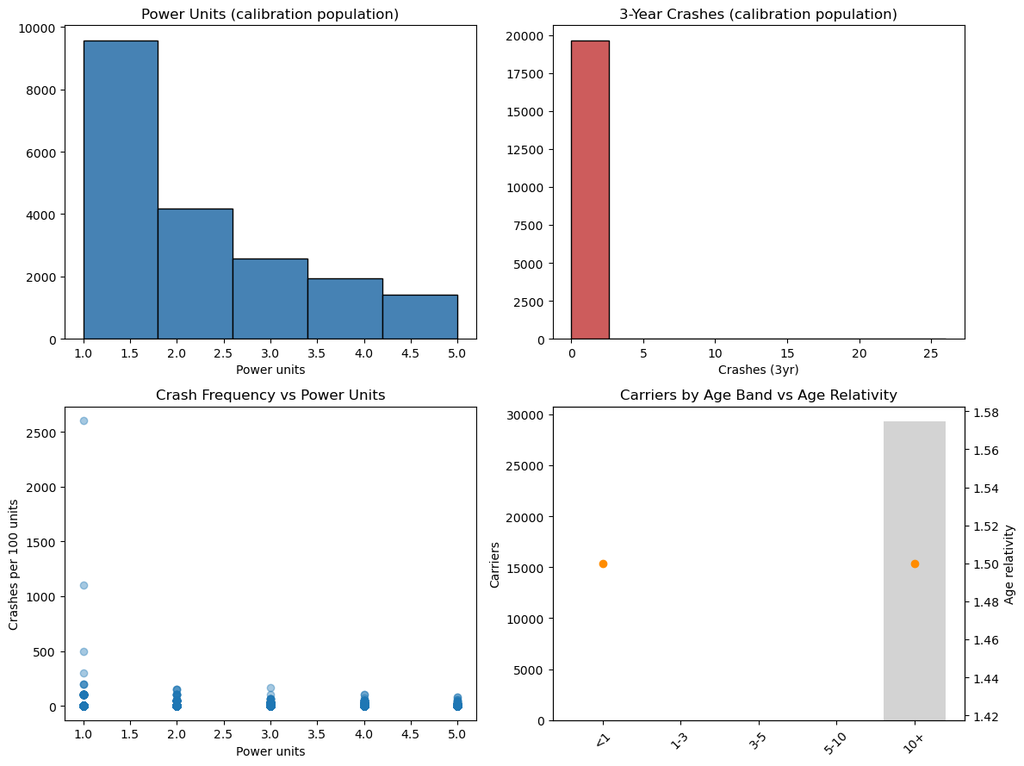

```python
# Trends & Analysis - basic charts

import matplotlib.pyplot as plt

fig, axes = plt.subplots(2, 2, figsize=(12, 9))

# 1. Power units and 3yr crashes -- the shape portfolio_frequency is calibrated on
axes[0, 0].hist(calibration["power_units"], bins=5, color="steelblue", edgecolor="black")
axes[0, 0].set_title("Power Units (calibration population)")
axes[0, 0].set_xlabel("Power units")

axes[0, 1].hist(calibration["crashes_3yr"], bins=10, color="indianred", edgecolor="black")
axes[0, 1].set_title("3-Year Crashes (calibration population)")
axes[0, 1].set_xlabel("Crashes (3yr)")

# 2. Crash frequency vs power units -- do small fleets really look noisier?
axes[1, 0].scatter(calibration["power_units"], calibration["crash_frequency_per_100_units"], alpha=0.4)
axes[1, 0].set_title("Crash Frequency vs Power Units")
axes[1, 0].set_xlabel("Power units")
axes[1, 0].set_ylabel("Crashes per 100 units")

# 3. Carrier counts by age band next to the age relativity
ax2 = axes[1, 1].twinx()
axes[1, 1].bar(age_stats["age_band"].astype(str), age_stats["carriers"], color="lightgray")
ax2.plot(age_stats["age_band"].astype(str), age_stats["relativity"], color="darkorange", marker="o")
axes[1, 1].set_title("Carriers by Age Band vs Age Relativity")
axes[1, 1].set_ylabel("Carriers")
ax2.set_ylabel("Age relativity")
axes[1, 1].tick_params(axis="x", rotation=45)

plt.tight_layout()
plt.show()
```

### Insights

```python
#Power units: the target market is heavily concentrated in very small fleets
#3-year crashes: most carriers have zero crashes
#Crash frequency vs power units: individual experience is extremely volatile
```